# r_plot_map

reference:  
[How to plot a Taiwan Map colored with Population by ggplot2](http://www.rpubs.com/OzuShi/348822)  
[R语言中国地图绘制](https://zhuanlan.zhihu.com/p/26708368) [用R画中国地图并标注城市位置](http://f.dataguru.cn/thread-330558-1-1.html)

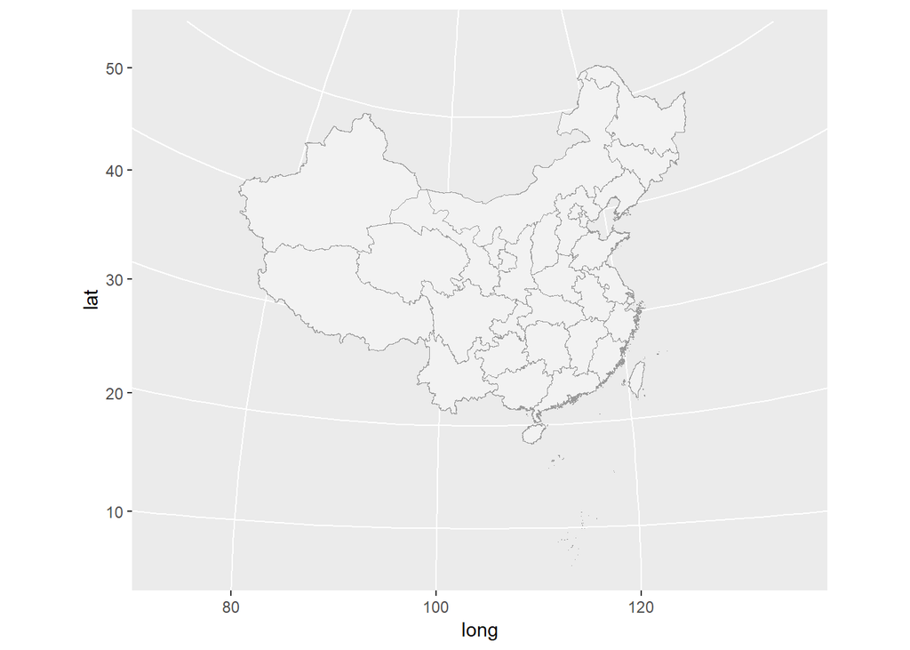

```r
library(maptools)
library(ggplot2)
library(plyr)
library(dplyr)
setwd("f:/R-notes/plot_map/") #确定文件路径

china_map <-readShapePoly("bou2_4p.shp") # 读取地图空间数据
china_map <- fortify(china_map) #转化为数据框
#china_data<-read.csv("chinaprovincecity.csv") #读取省会城市坐标

ggplot()+

  geom_polygon(data=china_map, aes(x=long, y=lat, group=group),fill="grey95", colour="grey60",size=0.25)+ #中国地图

  #geom_point(data=china_data, aes(x = jd,y = wd),size=4,fill="black", alpha=1,shape=21, colour="white")+ #散点图

coord_map("polyconic")
```

```r
# + theme_nothing()#图表元素设定 这一行代码过时了
```

[R语言绘制地图](https://segmentfault.com/a/1190000002890587)

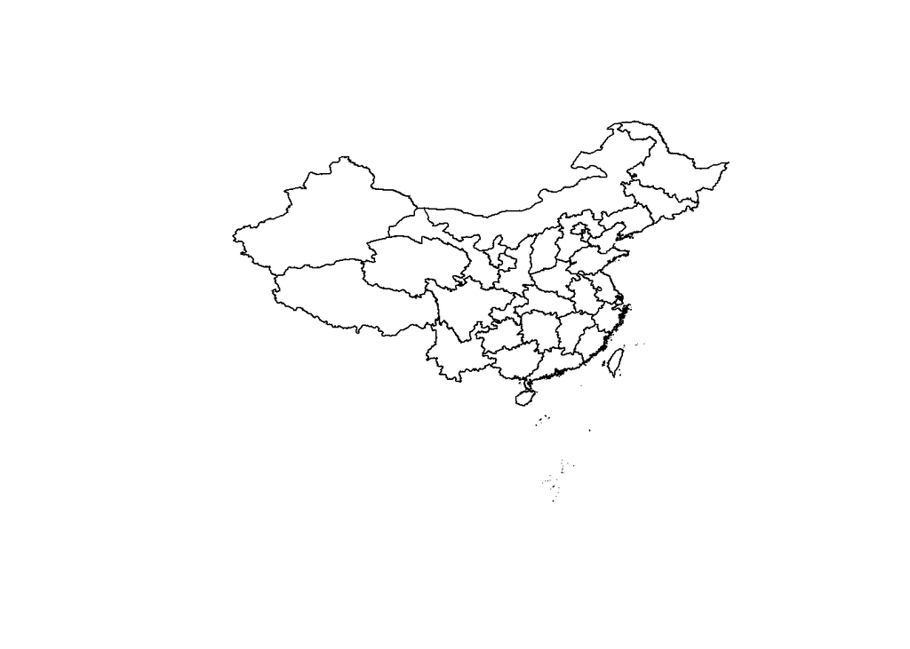

```r
library(maptools);
mapdata=readShapePoly('bou2_4p.shp')
plot(mapdata);
```

实际上python中用basemap画地图也是这个原理.多边形的个数不一定是925个,应该是900+. 读取bou2_4p.shp文件，在默认情况下会把dbf文件的信息也读取进来.

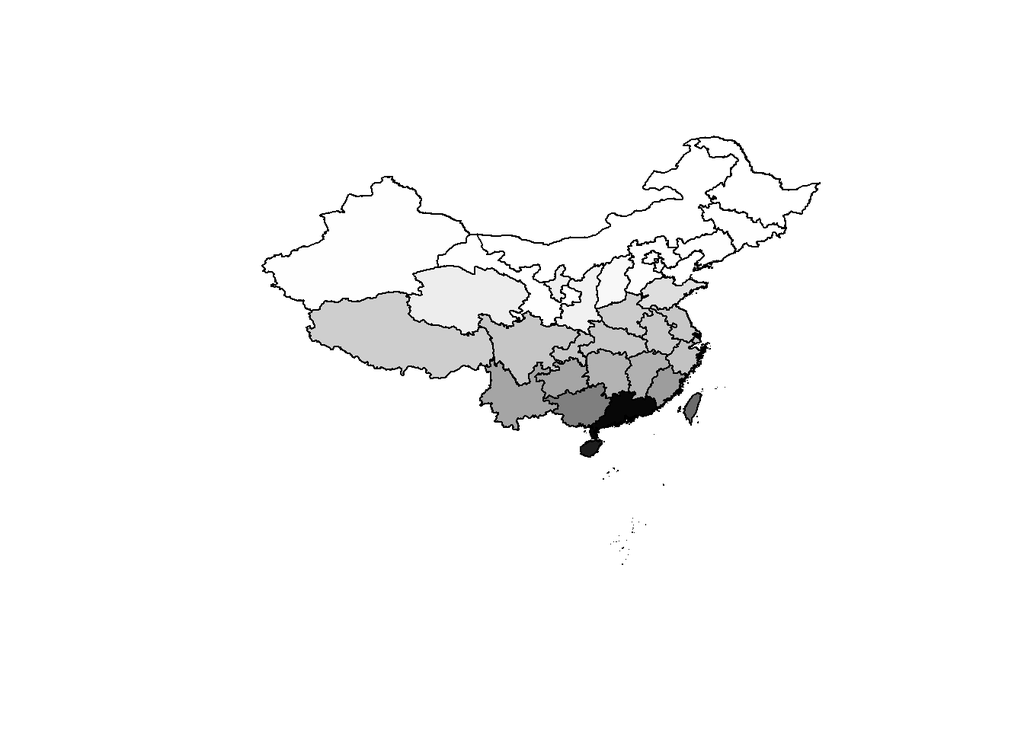

```r
plot(mapdata,col=gray(924:0/924));
```

```r
# mapdata[2]; # mapdata@data
# mapdata[2][1,]
```

```r
1:6 %in% 0:10
```

```
## [1] TRUE TRUE TRUE TRUE TRUE TRUE
```

```r
0:10 %in% 1:6
```

```
##  [1] FALSE  TRUE  TRUE  TRUE  TRUE  TRUE  TRUE FALSE FALSE FALSE FALSE
```

```r
a = c(5,7,2,9)
ifelse(a %% 2 == 0,"even","odd")
```

```
## [1] "odd"  "odd"  "even" "odd"
```

```r
x = 1:3
y = 2:4
print(x)
```

```
## [1] 1 2 3
```

```r
print(y)
```

```
## [1] 2 3 4
```

```r
which(x == y)
```

```
## integer(0)
```

```r
x = c(1,3,4,5)
y = c(1,2,4,6)
print(x)
```

```
## [1] 1 3 4 5
```

```r
print(y)
```

```
## [1] 1 2 4 6
```

```r
which(x == y) # 返回相等元素的索引
```

```
## [1] 1 3
```

Embed this directly in the Rmarkdown script that contains the Chinese character comment(s): https://stackoverflow.com/questions/41717781/warning-input-string-not-available-in-this-locale

```r
#Sys.setlocale('LC_ALL','C')
getColor=function(mapdata,provname,provcol,othercol){
  f = function(x,y) ifelse(x %in% y,which(y==x),0);
  # x是一个向量,y也是一个向量,如果x与y的对应位置的元素相同,则填充该元素在y中的索引,若不相同则记为0
  colIndex=sapply(mapdata@data$NAME,f,provname);
  #colIndex :925维的向量,不上色的地方对应的元素 存的是0,
  #上色的地方对应的元素 存的是要上的颜色的对应的索引,
  #注:索引从1开始
  color_vec=c(othercol,provcol)[colIndex+1];
  return(color_vec);
}
```

这一行比较难理解

```r
 f = function(x,y) ifelse(x %in% y,which(y==x),0);
```

用python改写下

```python
def f(x,y):
  """
  y == unique(y)
  """
  res = []
  for item in x:
    has_equal_num = False
    for idx,item_ in enumerate(y):
      if item_ == item:
        res.append(idx+1)
        has_equal_num = True
        break
    if not has_equal_num:
      res.append(0)
```

联想python中pandas的`df.['列1']apply(f)`,对列中的每一行并行应用函数f()

```r
f = function(x,y) ifelse(x %in% y,which(y==x),0);
sapply(mapdata@data$NAME,f,provname)
```

这两行配合起来,相当于对x的每个元素并行使用f函数,且参数y皆为provname,最后将每个函数调用返回的结果按顺序组装成向量

其中mapdata是存放地图数据的变量，在上面的例子中就是x，provname是需要改变颜色的地区的名称，provcol是对应于provname的代表颜色的向量（名称和数字均可），othercol是其它地区的颜色。举例如下：

```r
othercol = 'white'
provcol=c("red","green","yellow","purple");
temp = c(othercol,provcol)
print(temp)
```

```
## [1] "white"  "red"    "green"  "yellow" "purple"
```

```r
colIndex = c(0,2,3,1,4,0,0,0)
t = colIndex + 1
print(t)
```

```
## [1] 1 3 4 2 5 1 1 1
```

```r
color_vec=c(othercol,provcol)[t];
print(color_vec)
```

```
## [1] "white"  "green"  "yellow" "red"    "purple" "white"  "white"  "white"
```

R语言中向量语法和python中numpy相当不一样,color_vec=c(othercol,provcol)[t]; 其实可以理解为

```python
merge = othercol + provcol
color_vec = []
for idx in t:
  color_vec.append(merge[idx])
```

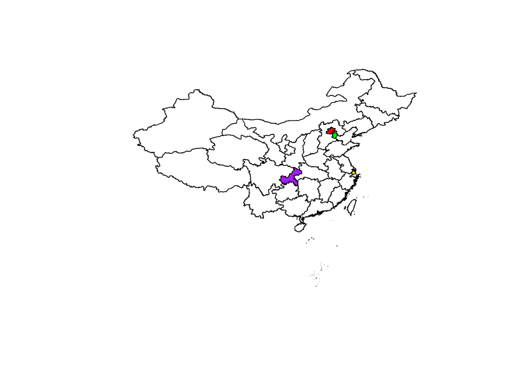

```r
provname=c("北京市","天津市","上海市","重庆市");
provcol=c("red","green","yellow","purple");
plot(mapdata,col=getColor(mapdata,provname,provcol,"white"));
```

注意provname一定要写地区的全称，写法可以参照下面这条命令生成的向量：  
as.character(na.omit(unique(mapdata@data$NAME)));

由此生成的向量有33个元素，少了澳门特别行政区，这是这个数据中的一块瑕疵。在x$att.data的第899行有一个NA，不知道它代表的是否就是澳门。

利用类似的方法就可以根据自己的需要对不同的区域进行着色，下面再举一例。从国家统计局获取2007年我国各地区的人口数据，然后根据人口的多少对各省份进行着色。程序如下：

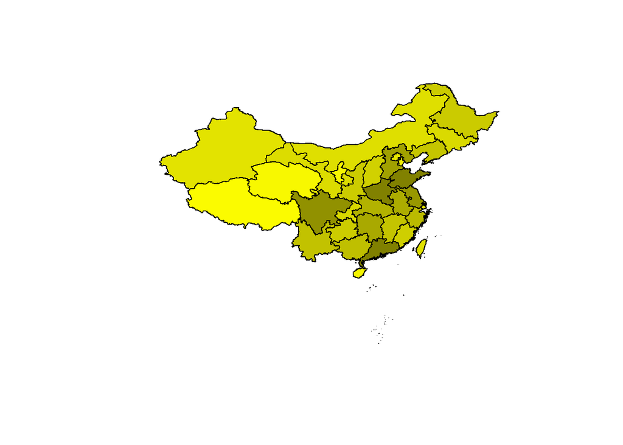

```r
provname=c("北京市","天津市","河北省","山西省","内蒙古自治区",
                "辽宁省","吉林省","黑龙江省","上海市","江苏省",
                "浙江省","安徽省","福建省","江西省","山东省",
                "河南省","湖北省","湖南省","广东省",
                "广西壮族自治区","海南省","重庆市","四川省","贵州省",
                "云南省","西藏自治区","陕西省","甘肃省","青海省",
                "宁夏回族自治区","新疆维吾尔自治区","台湾省",
                "香港特别行政区");
pop=c(1633,1115,6943,3393,2405,4298,2730,3824,1858,7625,
                5060,6118,3581,4368,9367,9360,5699,6355,9449,
                4768,845,2816,8127,3762,4514,284,3748,2617,
                552,610,2095,2296,693);
provcol=rgb(red=1-pop/max(pop)/2,green=1-pop/max(pop)/2,blue=0);
plot(mapdata,col=getColor(mapdata,provname,provcol,"white"),xlab="",ylab="");
```

局部  
此外，在绘制地图的过程中，还有一个比较有用的参数是recs，它是一个由多边形ID组成的向量，表示在地图中只画出这些ID所代表的区域。利用这个参数，就可以画出某一部分的地图，例如下面的例子是我国中部六省的地图：

http://f.dataguru.cn/thread-330558-1-1.html(用R画中国地图并标注城市位置)

```r
getID=function(mapdata,provname){
  index=mapdata@data$NAME %in% provname; # bool vector
  ids=rownames(mapdata@data[index,]); # rownames 返回行号的向量
  return(as.numeric(ids));
}


midchina=c("河南省","山西省","湖北省","安徽省","湖南省","江西省");
#plot(mapdata,recs=getID(mapdata,midchina),col="blue",ol="white",xlab="",ylab="");
```

新版本的maptools包的绘图函数已经取消了recs这个参数,替代方法如下:

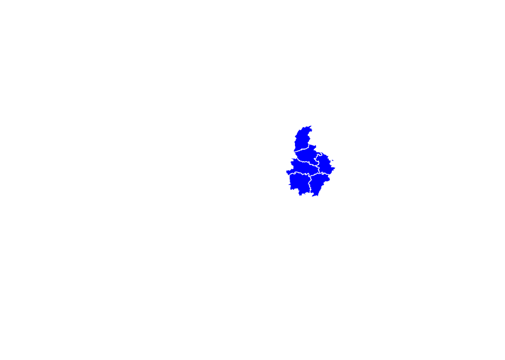

```r
midchina=c("河南省","山西省","湖北省","安徽省","湖南省","江西省");
plot(mapdata,col=getColor(mapdata,midchina,rep('blue',6),'white'),border="white",xlab="",ylab="")
```